# Avaliacao Individual - Multivariada I

Leandro Sampaio Silva

30 de junho de 2018

https://stats.stackexchange.com/questions/76226/interpreting-the-residuals-vs-fitted-values-plot-for-verifying-the-assumptions http://sphweb.bumc.bu.edu/otlt/MPH-Modules/BS/R/R5_Correlation-Regression/R5_Correlation-Regression7.html

Para esse exercicio utilizaremos os dados de `Prestige`, presente no pacote `car`

```r
if(!require(car)){install.packages("car")}
data("Prestige")
Prestige<-na.omit(Prestige);
summary(Prestige)
```

```
##    education          income          women           prestige
##  Min.   : 6.380   Min.   : 1656   Min.   : 0.000   Min.   :17.30
##  1st Qu.: 8.445   1st Qu.: 4250   1st Qu.: 3.268   1st Qu.:35.38
##  Median :10.605   Median : 6036   Median :14.475   Median :43.60
##  Mean   :10.795   Mean   : 6939   Mean   :28.986   Mean   :47.33
##  3rd Qu.:12.755   3rd Qu.: 8226   3rd Qu.:52.203   3rd Qu.:59.90
##  Max.   :15.970   Max.   :25879   Max.   :97.510   Max.   :87.20
##      census       type
##  Min.   :1113   bc  :44
##  1st Qu.:3116   prof:31
##  Median :5132   wc  :23
##  Mean   :5400
##  3rd Qu.:8328
##  Max.   :9517
```

`education`: Quantidade m?dia de anos estudantes (1971). `income`: Ganho salarial m?dio, em d?lares (1971). `women`: Porcentagem de mulheres na profiss?o. `prestige`: Escore de prest?gio, segundo Pineo-Porter para ocupacoes, a partir de inventarios realizados na decada de 1960. `census`: Codigo de ocupacao segundo o censo canadense. `type`: Tipo de ocupacao. Um fator com n?veis: `bc`, *Blue Collar*; `prof`, *Professional*, *Managerial*, e *Technical*; `wc`, *White Collar*

Construindo o modelo geral (`mod_geral`), com todas as variaveis para explicar o prestigio social das pessoas:

```r
mod_geral <- lm(prestige~., Prestige); summary(mod_geral)
```

```
##
## Call:
## lm(formula = prestige ~ ., data = Prestige)
##
## Residuals:
##      Min       1Q   Median       3Q      Max
## -12.9863  -4.9813   0.6983   4.8690  19.2402
##
## Coefficients:
##               Estimate Std. Error t value Pr(>|t|)
## (Intercept) -1.213e+01  8.018e+00  -1.513  0.13380
## education    3.933e+00  6.535e-01   6.019 3.64e-08 ***
## income       9.946e-04  2.601e-04   3.824  0.00024 ***
## women        1.310e-02  3.019e-02   0.434  0.66524
## census       1.156e-03  6.183e-04   1.870  0.06471 .
## typeprof     1.077e+01  4.676e+00   2.303  0.02354 *
## typewc       2.877e-01  3.139e+00   0.092  0.92718
## ---
## Signif. codes:  0 '***' 0.001 '**' 0.01 '*' 0.05 '.' 0.1 ' ' 1
##
## Residual standard error: 7.037 on 91 degrees of freedom
## Multiple R-squared:  0.841,  Adjusted R-squared:  0.8306
## F-statistic: 80.25 on 6 and 91 DF,  p-value: < 2.2e-16
```

## 2. Analise grafica do modelo

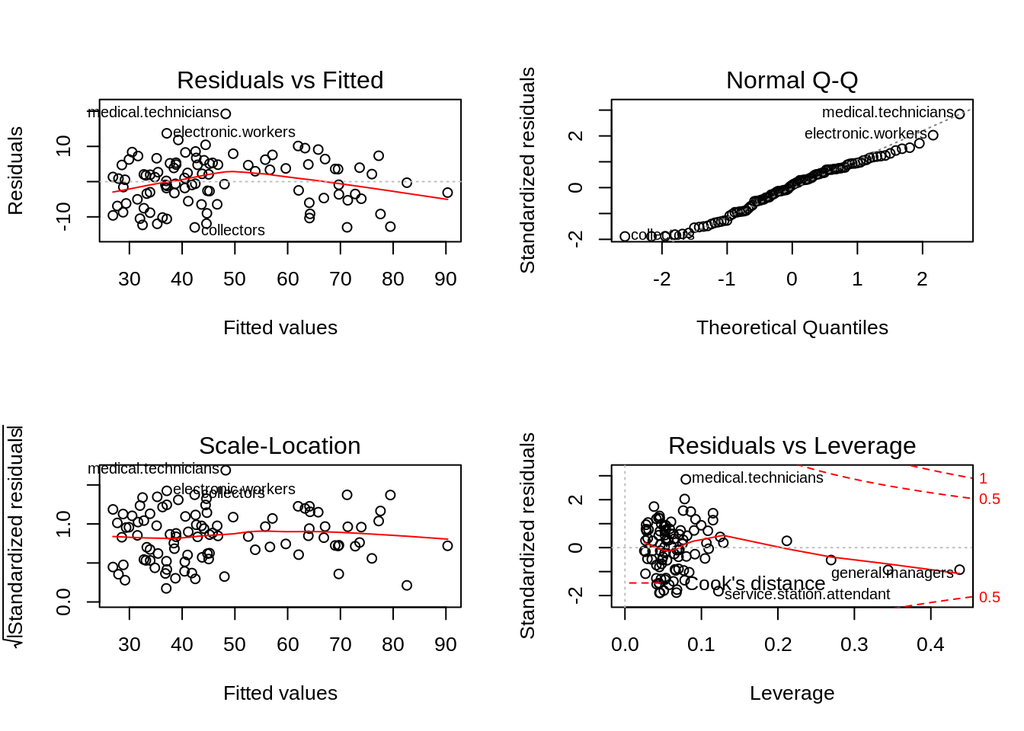

```r
par(mfrow=c(2,2))
plot(mod_geral)
```

### A. Questao:

Quais sao os pressupostos que devemos analisar nesses graficos? Existe algum que parece estar sendo violado? Explique. **R:** *Os pressupostos que podemos analisar a partir dos graficos são: de linearidade, de normalidade, Homocedastico, outliers. Se constata a presença de alguns outliers, tendo também afetado a linearidade dos residuos, talvez a remoção dos mesmos permitiria um melhor desenho da reta, contudo os residuos ainda seguem uma normalidade e mantem a homocedasticidade*

### B. Questao:

Por que e importante examinar a suposicao de distribuicao normal dos res?duos? **R:** *Porque caso algum dos pressupostos sejam violados, podemos cair em um cenario de falso positivo para a linearidade dos residuos sobre uma “reta”.*

## 3. Correlacao de variveis

Visualizacao da correlacao entre variaveis:

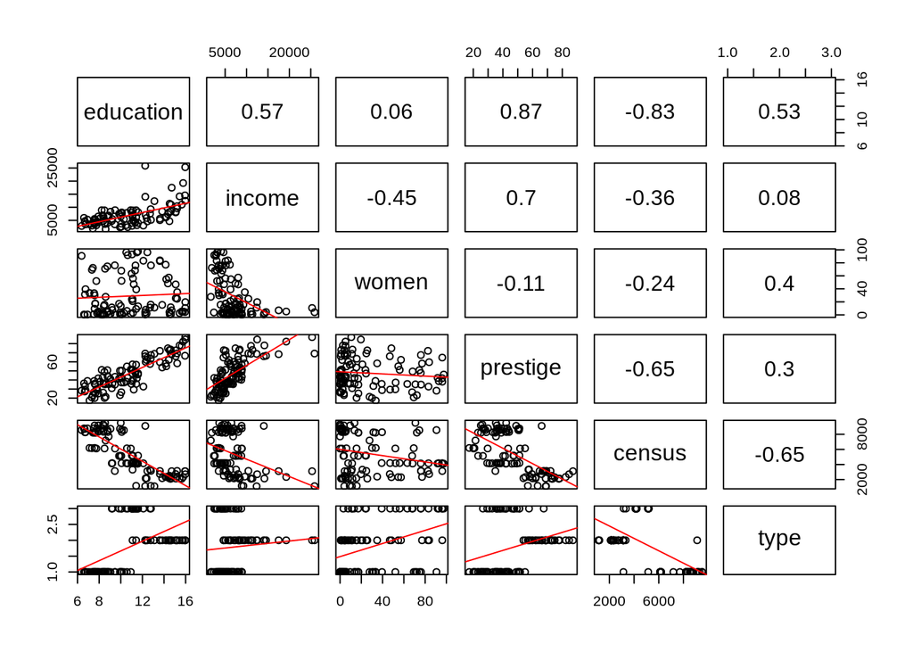

```r
fcor<-function(x,y){
  par(usr=c(0,1,0,1))
  txt<- as.character(round(cor(x,y),2))
  text(0.5, 0.5, txt, cex=1.5)
}

flines <-function(x,y){
        points(x,y)
        abline(lm(y~x), col="red")
}

pairs(Prestige,
      lower.panel= flines,
      upper.panel = fcor)
```

Analise VIF:

```r
vif(mod_geral)
```

```
##                GVIF Df GVIF^(1/(2*Df))
## education  6.321775  1        2.514314
## income     2.368891  1        1.539120
## women      1.757839  1        1.325835
## census     5.396127  1        2.322957
## type      10.362795  2        1.794193
```

### A. Questao:

De que maneira as variaveis correlacionadas podem afetar a interpretacao da equaacao da regressao? Explique. **R:** *Altos valores de Erros padrões para os coeficientes;Coeficiente geral pode se mostrar significativo, mas seus coeficientes individuais podem não ser significativos; Sinal incorreto de coeficientes; e instabilidade quando as VI forem analisadas separadamente podem mostrar importâncias diferentes quando analisadas em conjunto.*

### B. Questao:

Qual a diferenca entre variaveis independentes interativas com vari?veis independentes correlacionadas? Explique. **R:** *Variaveis ind. interativas afetam-se de forma mutua, normalmente apresentando um fator de proporção entre si, enquanto variaveis ind. correlacionadas normalmente obedecem um comportamento similar mas não associado.*

## 4. Mudanca do modelo com analises VIF e grafica

Escolha, a partir dos exames previos anteriores, algumas varivveis independentes para propor um novo modelo. Substitua o `---` pelo nome das vari?veis (`education`, `income`, `women`, `census` e/ou `type`), separadas por `+`:

```r
mod_novo <- lm(prestige ~
                      income+education,  # Substitua --- pelo nome das vari?veis que julga importante
               Prestige)
summary(mod_novo)
```

```
##
## Call:
## lm(formula = prestige ~ income + education, data = Prestige)
##
## Residuals:
##      Min       1Q   Median       3Q      Max
## -16.9367  -4.8881   0.0116   4.9690  15.9280
##
## Coefficients:
##               Estimate Std. Error t value Pr(>|t|)
## (Intercept) -7.6210352  3.1162309  -2.446   0.0163 *
## income       0.0012415  0.0002185   5.682 1.45e-07 ***
## education    4.2921076  0.3360645  12.772  < 2e-16 ***
## ---
## Signif. codes:  0 '***' 0.001 '**' 0.01 '*' 0.05 '.' 0.1 ' ' 1
##
## Residual standard error: 7.45 on 95 degrees of freedom
## Multiple R-squared:  0.814,  Adjusted R-squared:  0.8101
## F-statistic: 207.9 on 2 and 95 DF,  p-value: < 2.2e-16
```

Verifica??o grafica do novo modelo (`mod_novo`):

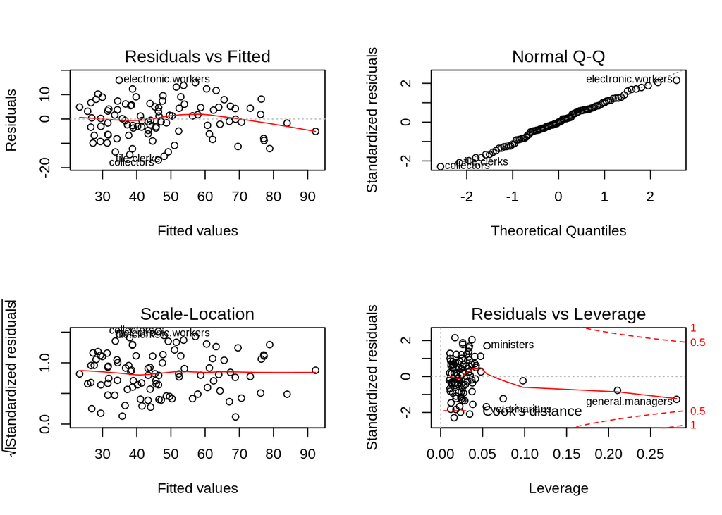

```r
par(mfrow=c(2,2))
plot(mod_novo)
```

Correlacao das variaveis independentes:

```r
vif(mod_novo)
```

```
##    income education
##  1.491621  1.491621
```

### Questao:

O novo modelo parece adequado? Explique. **R**: *As variavel correlacionada não esta mais presente, as variaveis que pouco agregavam ao modelo também foram removidas, A linearidade dos residuos segue prejudicada e ainda e um ponto a ser observado*

## 5. ANOVA dos modelos

Compare os modelos antigo (`mod_geral`) e novo (`mod_novo`) usando `anova`:

```r
anova(mod_novo, mod_geral)
```

```
## Analysis of Variance Table
##
## Model 1: prestige ~ income + education
## Model 2: prestige ~ education + income + women + census + type
##   Res.Df    RSS Df Sum of Sq      F   Pr(>F)
## 1     95 5272.4
## 2     91 4505.9  4    766.58 3.8704 0.005985 **
## ---
## Signif. codes:  0 '***' 0.001 '**' 0.01 '*' 0.05 '.' 0.1 ' ' 1
```

### Questao:

Qual dos dois modelos voce? julga mais adequado? Explique. **R**: *Depende do uso, no caso para predição eu manteria o segundo modelo, visto que os modelos de predição normalmente não são afetados por variaveis correlacionadas, contudo para os demais casos eu escolheria o primeiro.*

# Interpretacao de modelos

## 6. Correlacao parcial

Ainda utilizando os dados `Prestige`, podemos observar certa correlacao entre as variaveis `prestige`, `income` e `education`:

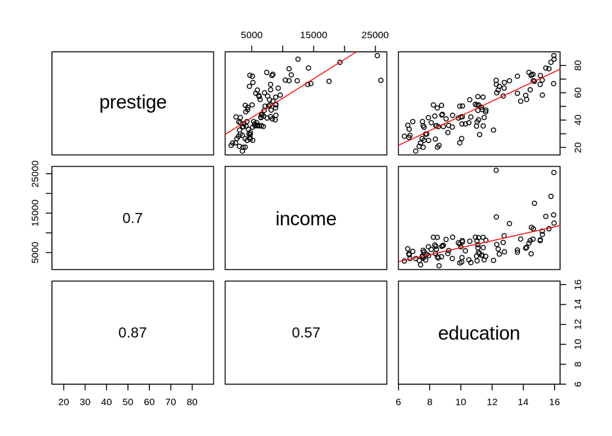

```r
pre<-Prestige[c('prestige', 'income', 'education')]
pairs(pre,
      lower.panel = fcor,
      upper.panel = flines)
```

E um pesquisador ficou em duvida para ver o quanto do `prestige` dado pela educa??o (`education`) seria na verdade decorrente dos ganhos financeiros da profiss?o (`income`). Para isso ele utilizou o c?lculo para as correla??es parciais entre as vari?veis `income`, `education` para explicar `prestige`:

```r
rho_parcial <- function(Y=Y, X1=X1, X2=X2){
  rho_Y_X1 <- cor(Y, X1)
  rho_Y_X2 <- cor(Y, X2)
  rho_X1X2 <- cor(X1, X2)
  rho_parcial_X1 <- (rho_Y_X1 -
                 (rho_Y_X2*rho_X1X2))/
                   sqrt(1-rho_X1X2^2)
  return(rho_parcial_X1)
}
prestige <- Prestige$prestige
income <- Prestige$income
education <- Prestige$education
so_income <-rho_parcial(Y=prestige, X1=income, X2=education)^2
so_education <- rho_parcial(Y=prestige, X1=education, X2=income)^2
education_income <-cor(prestige, income)^2 - so_income
nao_explicado <- 1- (so_income + so_education + education_income)

t(data.frame(so_income, so_education, education_income, nao_explicado))
```

```
##                        [,1]
## so_income        0.06321563
## so_education     0.31935865
## education_income 0.43142854
## nao_explicado    0.18599718
```

### Questao:

Qual dos dois fatores (`education` e `income`) voc? julga mais importante para explicar `prestige`? Explique. **R**: *Só education já é suficiente por explicar 31% do prestige, enquanto income é responsável por somente 6% ficando, mesmo a combinação de ambas não justificaria representa sometne 43% ou seha 12% a mais, tendo ainda a ser considerado o grau de colinearidade entre ambas*

## 7. Modelo sem interacao

O modelo entre `prestige` com `education` e `type` foi montado a seguir:

```r
mod_sem <- lm(prestige ~ type + education, Prestige)
summary(mod_sem)
```

```
##
## Call:
## lm(formula = prestige ~ type + education, data = Prestige)
##
## Residuals:
##     Min      1Q  Median      3Q     Max
## -19.410  -5.508   1.360   5.694  17.171
##
## Coefficients:
##             Estimate Std. Error t value Pr(>|t|)
## (Intercept)  -2.6982     5.7361  -0.470   0.6392
## typeprof      6.1424     4.2590   1.442   0.1526
## typewc       -5.4585     2.6907  -2.029   0.0453 *
## education     4.5728     0.6716   6.809 9.16e-10 ***
## ---
## Signif. codes:  0 '***' 0.001 '**' 0.01 '*' 0.05 '.' 0.1 ' ' 1
##
## Residual standard error: 7.814 on 94 degrees of freedom
## Multiple R-squared:  0.7975, Adjusted R-squared:  0.791
## F-statistic: 123.4 on 3 and 94 DF,  p-value: < 2.2e-16
```

### Questao:

Interprete os coeficientes colocados no `summary`. **R**: *Education apresenta uma grande significancia para o modelo, contudo somente typewc apresenta alguma significancia a ser considerada além do educaition*

## 8. Modelo com intera??o

O modelo entre `prestige` com `education` e `type` foi modificado, levando em considera??o a intera??o a seguir:

```r
mod_com <- lm(prestige ~ type*education, Prestige)
summary(mod_com)
```

```
##
## Call:
## lm(formula = prestige ~ type * education, data = Prestige)
##
## Residuals:
##      Min       1Q   Median       3Q      Max
## -19.7095  -5.3938   0.8125   5.3968  16.1411
##
## Coefficients:
##                    Estimate Std. Error t value Pr(>|t|)
## (Intercept)         -4.2936     8.6470  -0.497    0.621
## typeprof            18.8637    16.8881   1.117    0.267
## typewc             -24.3833    21.7777  -1.120    0.266
## education            4.7637     1.0247   4.649 1.11e-05 ***
## typeprof:education  -0.9808     1.4495  -0.677    0.500
## typewc:education     1.6709     2.0777   0.804    0.423
## ---
## Signif. codes:  0 '***' 0.001 '**' 0.01 '*' 0.05 '.' 0.1 ' ' 1
##
## Residual standard error: 7.827 on 92 degrees of freedom
## Multiple R-squared:  0.8012, Adjusted R-squared:  0.7904
## F-statistic: 74.14 on 5 and 92 DF,  p-value: < 2.2e-16
```

### Questao:

O que mudou entre o modelo `mod_sem` e `mod_com`? Explique **R**: *No caso foi considerada o grau de correlacao entre as interações das variaveis education e type. Contudo education por si só foi a unica a apresentar uma significancia como no caso anterior. N~ao houve grande mundanca entre o R-squared dos modelos comparados.*

## 9. Comparacao entre os modelos

```r
anova(mod_sem, mod_com)
```

```
## Analysis of Variance Table
##
## Model 1: prestige ~ type + education
## Model 2: prestige ~ type * education
##   Res.Df    RSS Df Sum of Sq      F Pr(>F)
## 1     94 5740.0
## 2     92 5636.5  2    103.52 0.8448  0.433
```

## 10. Usando `predict`

A partir do seu modelo constru?do, preveja o prest?gio `prestige` de uma profiss?o que n?o existia em 1971, mas que existe hoje: [Cientista de Dados](https://exame.abril.com.br/carreira/profissao-mais-sexy-do-seculo-21-segue-em-alta-no-brasil/), considerada a profiss?o mais *sexy* atualmente… Para isso, utilize os valores aproximados para essa profissao, construindo um `data.frame`. Os comandos a seguir j? est?o feitos:

```r
data_scientist <- data.frame(education = 14,#Fonte: https://goo.gl/jTZdzX
                             income = 19,1, #Fonte: https://goo.gl/yWcqBS e https://goo.gl/CNku38
                             women = 1/3,   #Fonte: https://goo.gl/wxN543
                             type = 'prof')
```

Agora, a partir do seu modelo (coloque o nome do seu modelo escolhido no lugar de `---` a seguir), responda qual seria o *prest?gio* de um cientista de dados no ano de 1971.

```r
predict(mod_sem,  # Substitua --- pelo nome do modelo que julga melhor
        data_scientist,
        interval = "confidence")
```

```
##        fit      lwr      upr
## 1 67.46339 64.67444 70.25233
```

Para finalizar, uma ultima questao:

### Questao:

Voce consegue encontrar uma equacao de regressao que seja aceitavel como estatisticamente significante, mas que nao ofereca valor interpretativo para fins de gerenciamento? Explique. **R**: *O Quarteto de Anscombe da uma serie de perfeitos exemplos de equacoes estatisticamente significantes, mas de pouca relevância para qualquer area em em que for usada. A equacao não pode ser considerada um preditor, caso a pesquisa ou mesmo as amostras sejam consideradas falhas, a equacao de tera pouca significancia gerencial para qualquer seja o resultado estatistico*